# R-Happiness-Index-Model

```r
library(readr)
library(ggplot2)
library(datasets)
library(Hmisc)
world.happiness <- read.csv("2015.csv")
```

```r
summary(world.happiness)
```

```
##    Country             Region          Happiness.Rank   Happiness.Score
##  Length:158         Length:158         Min.   :  1.00   Min.   :2.839
##  Class :character   Class :character   1st Qu.: 40.25   1st Qu.:4.526
##  Mode  :character   Mode  :character   Median : 79.50   Median :5.232
##                                        Mean   : 79.49   Mean   :5.376
##                                        3rd Qu.:118.75   3rd Qu.:6.244
##                                        Max.   :158.00   Max.   :7.587
##  Standard.Error    Economy..GDP.per.Capita.     Family
##  Min.   :0.01848   Min.   :0.0000           Min.   :0.0000
##  1st Qu.:0.03727   1st Qu.:0.5458           1st Qu.:0.8568
##  Median :0.04394   Median :0.9102           Median :1.0295
##  Mean   :0.04788   Mean   :0.8461           Mean   :0.9910
##  3rd Qu.:0.05230   3rd Qu.:1.1584           3rd Qu.:1.2144
##  Max.   :0.13693   Max.   :1.6904           Max.   :1.4022
##  Health..Life.Expectancy.    Freedom       Trust..Government.Corruption.
##  Min.   :0.0000           Min.   :0.0000   Min.   :0.00000
##  1st Qu.:0.4392           1st Qu.:0.3283   1st Qu.:0.06168
##  Median :0.6967           Median :0.4355   Median :0.10722
##  Mean   :0.6303           Mean   :0.4286   Mean   :0.14342
##  3rd Qu.:0.8110           3rd Qu.:0.5491   3rd Qu.:0.18025
##  Max.   :1.0252           Max.   :0.6697   Max.   :0.55191
##    Generosity     Dystopia.Residual
##  Min.   :0.0000   Min.   :0.3286
##  1st Qu.:0.1506   1st Qu.:1.7594
##  Median :0.2161   Median :2.0954
##  Mean   :0.2373   Mean   :2.0990
##  3rd Qu.:0.3099   3rd Qu.:2.4624
##  Max.   :0.7959   Max.   :3.6021
```

#OBSERVATION: #There are no NA’s or inaccurate observations so we do not need to screen for accuracy.

```r
str(world.happiness)
```

```
## 'data.frame':    158 obs. of  12 variables:
##  $ Country                      : chr  "Switzerland" "Iceland" "Denmark" "Norway" ...
##  $ Region                       : chr  "Western Europe" "Western Europe" "Western Europe" "Western Europe" ...
##  $ Happiness.Rank               : int  1 2 3 4 5 6 7 8 9 10 ...
##  $ Happiness.Score              : num  7.59 7.56 7.53 7.52 7.43 ...
##  $ Standard.Error               : num  0.0341 0.0488 0.0333 0.0388 0.0355 ...
##  $ Economy..GDP.per.Capita.     : num  1.4 1.3 1.33 1.46 1.33 ...
##  $ Family                       : num  1.35 1.4 1.36 1.33 1.32 ...
##  $ Health..Life.Expectancy.     : num  0.941 0.948 0.875 0.885 0.906 ...
##  $ Freedom                      : num  0.666 0.629 0.649 0.67 0.633 ...
##  $ Trust..Government.Corruption.: num  0.42 0.141 0.484 0.365 0.33 ...
##  $ Generosity                   : num  0.297 0.436 0.341 0.347 0.458 ...
##  $ Dystopia.Residual            : num  2.52 2.7 2.49 2.47 2.45 ...
```

```r
#Checking the degrees of freedom for the mahalanobis cutoff.
#Summarizing mahal scores that are greater than the cutoff.
#Checking the cut off score for our Mahalanobis measure.

mahal = mahalanobis(world.happiness[, 3:12], colMeans(world.happiness[, 3:12]), cov(world.happiness[, 3:12], use = "pairwise.complete.obs"))

cutoff = qchisq(1-0.001, ncol(world.happiness[, 3:12]))
cutoff
```

```
## [1] 29.5883
```

```r
summary(mahal < cutoff)
```

```
##    Mode   FALSE    TRUE
## logical       3     155
```

```r
#Plotting the variable Economy GDP per Capita as the predictor of the Happiness Score
#Plotting the variable Life Expectancy as the predictor of the Happiness Score

#Graphing the relationship between Economy GDP per Capita and Happiness Score

m1 = lm(world.happiness$Happiness.Score ~ world.happiness$Economy..GDP.per.Capita.)
summary(m1)
```

```
##
## Call:
## lm(formula = world.happiness$Happiness.Score ~ world.happiness$Economy..GDP.per.Capita.)
##
## Residuals:
##      Min       1Q   Median       3Q      Max
## -1.96394 -0.48777 -0.07157  0.55947  1.60705
##
## Coefficients:
##                                          Estimate Std. Error t value Pr(>|t|)
## (Intercept)                                 3.499      0.133   26.30   <2e-16
## world.happiness$Economy..GDP.per.Capita.    2.218      0.142   15.62   <2e-16
##
## (Intercept)                              ***
## world.happiness$Economy..GDP.per.Capita. ***
## ---
## Signif. codes:  0 '***' 0.001 '**' 0.01 '*' 0.05 '.' 0.1 ' ' 1
##
## Residual standard error: 0.7174 on 156 degrees of freedom
## Multiple R-squared:  0.6099, Adjusted R-squared:  0.6074
## F-statistic: 243.9 on 1 and 156 DF,  p-value: < 2.2e-16
```

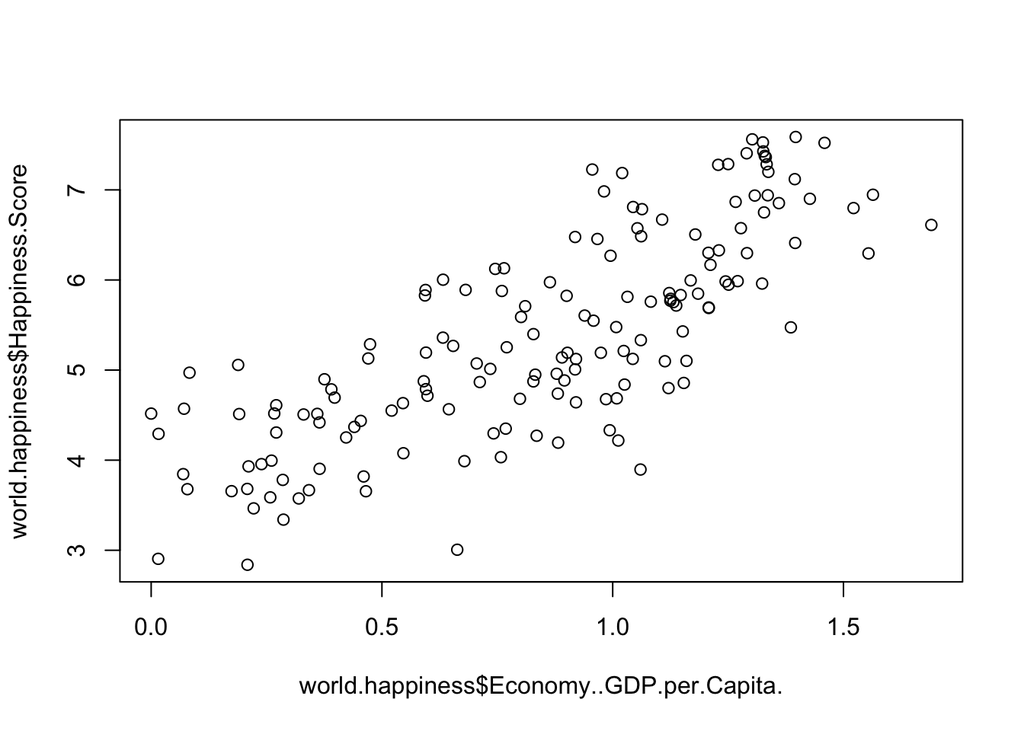

```r
plot(world.happiness$Economy..GDP.per.Capita., world.happiness$Happiness.Score)
```

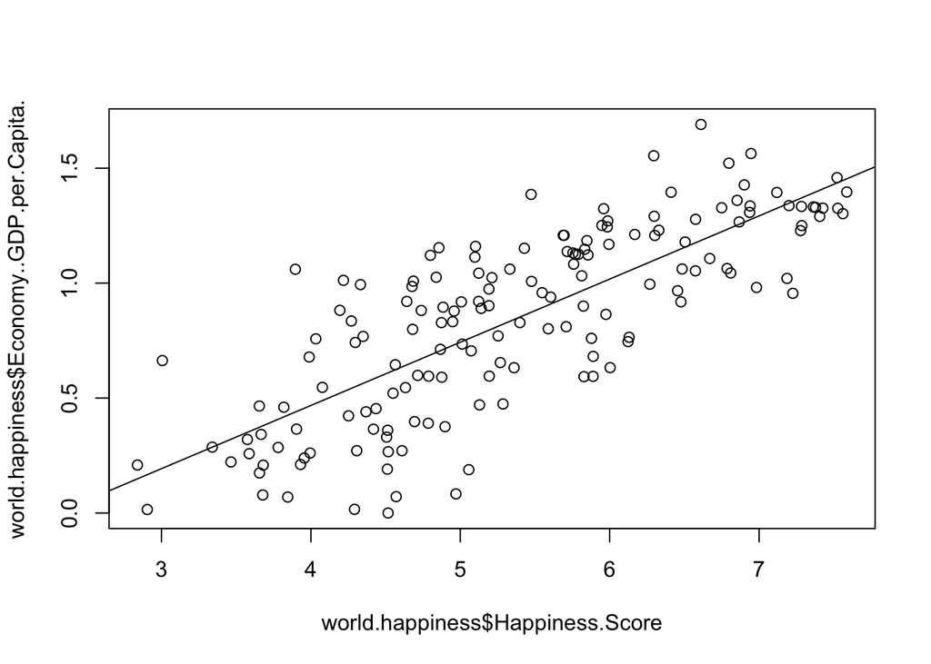

```r
{plot(world.happiness$Economy..GDP.per.Capita.~ world.happiness$Happiness.Score)
  abline(lm(world.happiness$Economy..GDP.per.Capita.~ world.happiness$Happiness.Score))}
```

#OBSERVATION- The relationship is linear between the Economy of a country and the Happiness Score

#Looking at the correlation coefficient to quantify the strength of the relationship

```r
cor(world.happiness$Economy..GDP.per.Capita., world.happiness$Happiness.Score)
```

```
## [1] 0.7809655
```

#Correlation coefficient for happiness score and Economy is 0.781

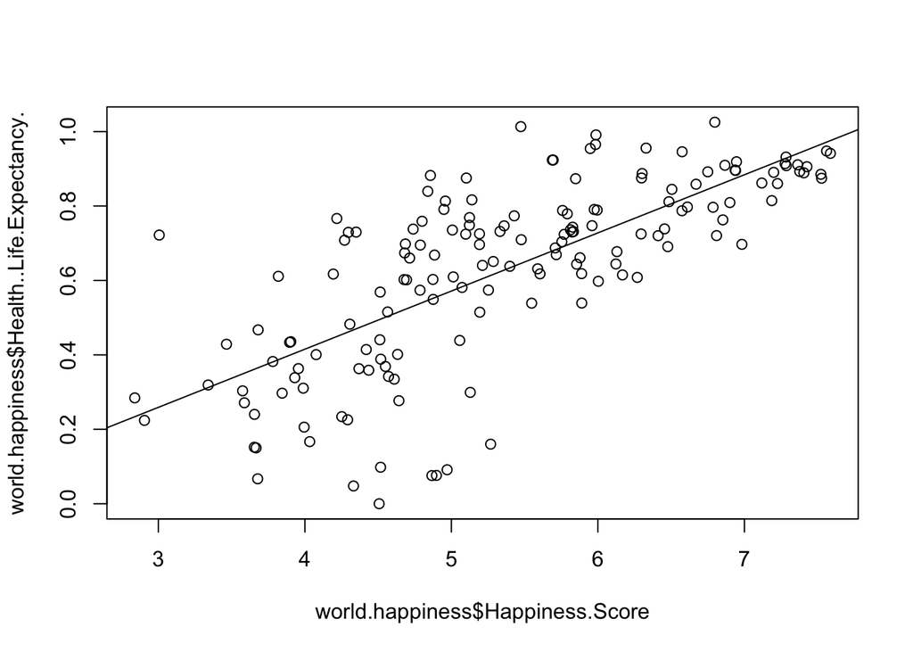

```r
{plot(world.happiness$Health..Life.Expectancy. ~ world.happiness$Happiness.Score)
  abline(lm(world.happiness$Health..Life.Expectancy. ~ world.happiness$Happiness.Score))}
```

OBSERVATION- The relationship is linear

```r
#Looking at the correlation coefficient to quantify the strength of the relationship

cor(world.happiness$Health..Life.Expectancy., world.happiness$Happiness.Score)
```

```
## [1] 0.7241996
```

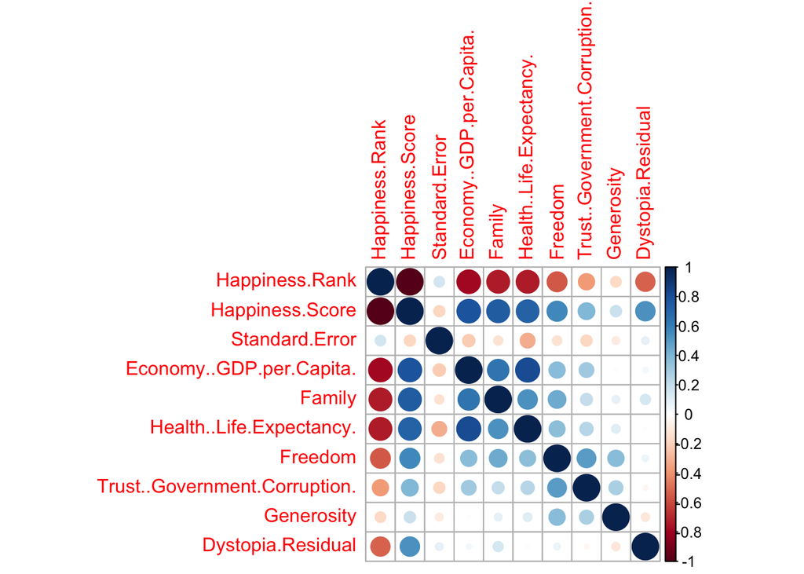

```r
#The correlation coefficient for happiness score and life expectancy is 0.724

#Plotting the correlation of the world happiness score against the independent variables
corrplot::corrplot(cor(world.happiness[, 3:12]))
```

```r
#plot_ss(x = world.happiness$Economy..GDP.per.Capita., y = world.happiness$Happiness.Score)

#plot_ss(x = world.happiness$Economy..GDP.per.Capita., y = world.happiness$Happiness.Score, showSquares = TRUE)

#Fitting the linar model (regression line)

m2 = lm(Happiness.Score ~ Economy..GDP.per.Capita., data = world.happiness)

summary(m2)
```

```
##
## Call:
## lm(formula = Happiness.Score ~ Economy..GDP.per.Capita., data = world.happiness)
##
## Residuals:
##      Min       1Q   Median       3Q      Max
## -1.96394 -0.48777 -0.07157  0.55947  1.60705
##
## Coefficients:
##                          Estimate Std. Error t value Pr(>|t|)
## (Intercept)                 3.499      0.133   26.30   <2e-16 ***
## Economy..GDP.per.Capita.    2.218      0.142   15.62   <2e-16 ***
## ---
## Signif. codes:  0 '***' 0.001 '**' 0.01 '*' 0.05 '.' 0.1 ' ' 1
##
## Residual standard error: 0.7174 on 156 degrees of freedom
## Multiple R-squared:  0.6099, Adjusted R-squared:  0.6074
## F-statistic: 243.9 on 1 and 156 DF,  p-value: < 2.2e-16
```

OBSERVATION-

#The Cofficient’s table in the summary fuction of m2 shows the linear model’s y-intercept and the coefficient of Economy GDP per Capita. #Therefore the least squares regression line for the linear model of Happiness Score is: #Happiness Score = 3.499 + 2.218* Economy..GDP.per.capita

#Multiple R-squared representsthe proportion of variability in the response variable that is explained by the explanatory variable, For this model 60.9% of the variability in the Happiness Score is explained by Economy GDP Per Capita.

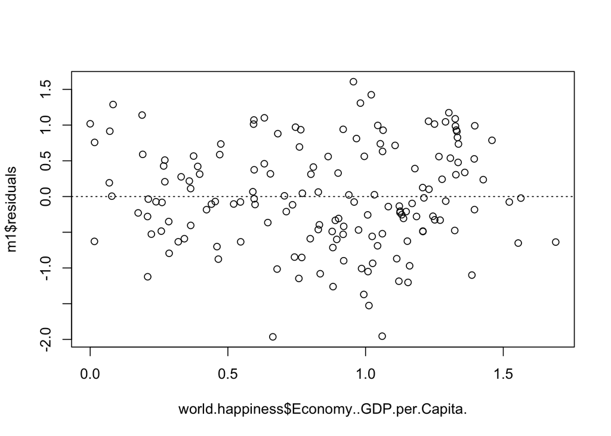

```r
#Checking to see if the linear model is reliable

#The relationship between Happiness Score and Economy GDP per Capita was linear
#We will now verify this condition with the residuals vs GDP per Capita

{plot(m1$residuals ~ world.happiness$Economy..GDP.per.Capita.)
  abline(h = 0, lty = 3)}
```

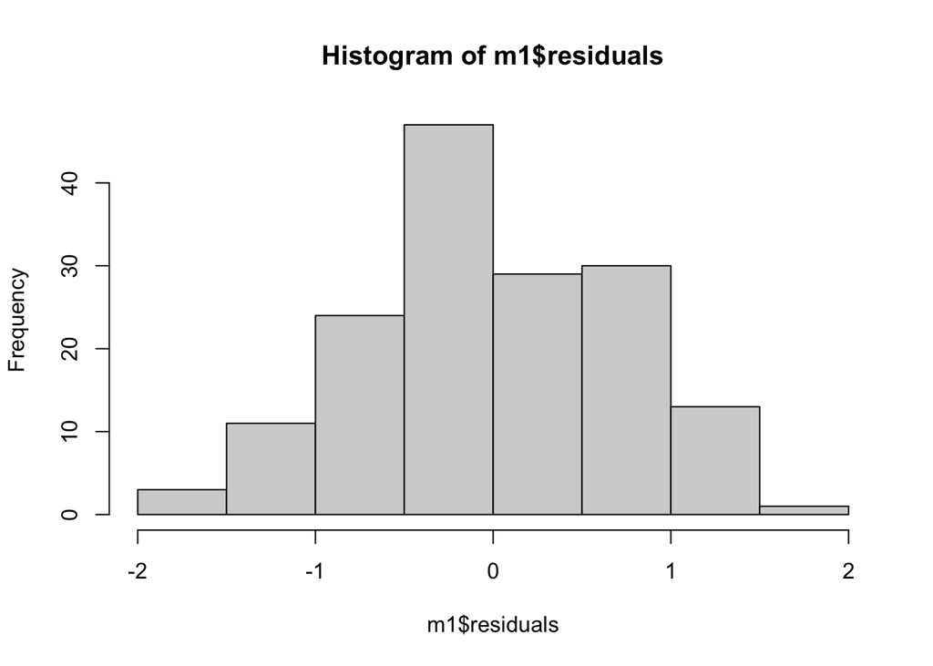

```r
hist(m1$residuals)
```

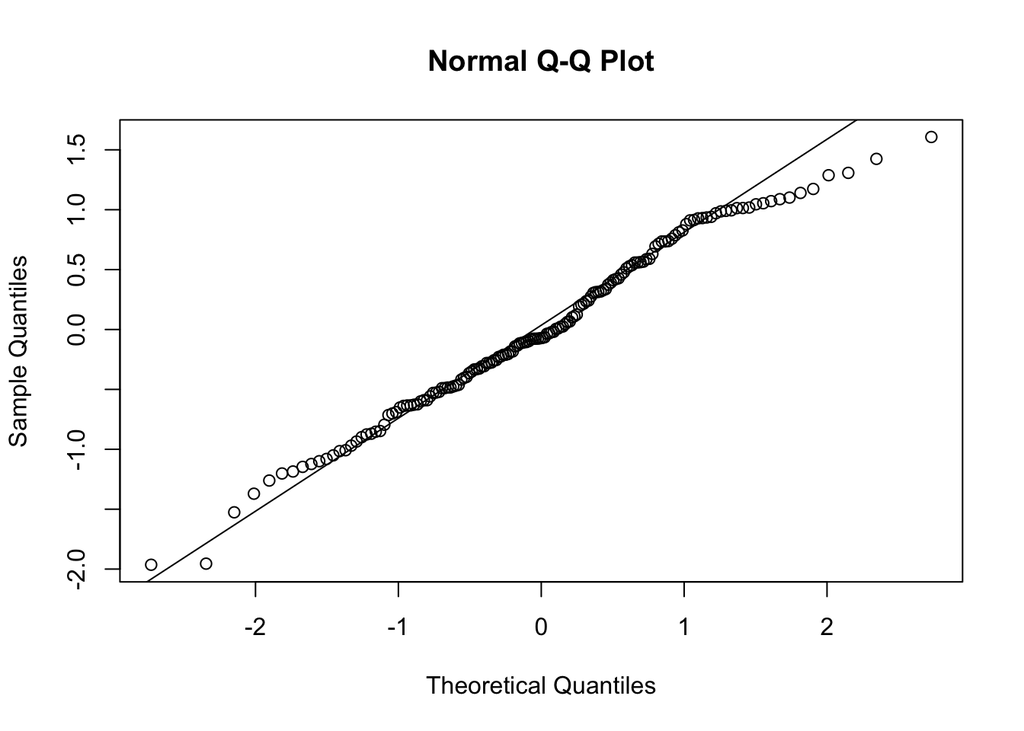

```r
{qqnorm(m1$residuals)
  qqline(m1$residuals)}
```

```r
#Checking the best predictor for Happiness Score
summary(lm(Happiness.Score ~ Economy..GDP.per.Capita., data = world.happiness))
```

```
##
## Call:
## lm(formula = Happiness.Score ~ Economy..GDP.per.Capita., data = world.happiness)
##
## Residuals:
##      Min       1Q   Median       3Q      Max
## -1.96394 -0.48777 -0.07157  0.55947  1.60705
##
## Coefficients:
##                          Estimate Std. Error t value Pr(>|t|)
## (Intercept)                 3.499      0.133   26.30   <2e-16 ***
## Economy..GDP.per.Capita.    2.218      0.142   15.62   <2e-16 ***
## ---
## Signif. codes:  0 '***' 0.001 '**' 0.01 '*' 0.05 '.' 0.1 ' ' 1
##
## Residual standard error: 0.7174 on 156 degrees of freedom
## Multiple R-squared:  0.6099, Adjusted R-squared:  0.6074
## F-statistic: 243.9 on 1 and 156 DF,  p-value: < 2.2e-16
```

```r
summary(lm(Happiness.Score ~ Family, data = world.happiness))
```

```
##
## Call:
## lm(formula = Happiness.Score ~ Family, data = world.happiness)
##
## Residuals:
##      Min       1Q   Median       3Q      Max
## -1.88667 -0.47443 -0.02976  0.61584  2.04955
##
## Coefficients:
##             Estimate Std. Error t value Pr(>|t|)
## (Intercept)   2.2902     0.2324   9.855   <2e-16 ***
## Family        3.1134     0.2262  13.766   <2e-16 ***
## ---
## Signif. codes:  0 '***' 0.001 '**' 0.01 '*' 0.05 '.' 0.1 ' ' 1
##
## Residual standard error: 0.7718 on 156 degrees of freedom
## Multiple R-squared:  0.5485, Adjusted R-squared:  0.5456
## F-statistic: 189.5 on 1 and 156 DF,  p-value: < 2.2e-16
```

#Multiple R Squared = 54.9%

```r
summary(lm(Happiness.Score ~ Freedom, data = world.happiness))
```

```
##
## Call:
## lm(formula = Happiness.Score ~ Freedom, data = world.happiness)
##
## Residuals:
##      Min       1Q   Median       3Q      Max
## -2.61618 -0.64097  0.02194  0.82129  1.96886
##
## Coefficients:
##             Estimate Std. Error t value Pr(>|t|)
## (Intercept)   3.5252     0.2274  15.505  < 2e-16 ***
## Freedom       4.3174     0.5006   8.624 6.88e-15 ***
## ---
## Signif. codes:  0 '***' 0.001 '**' 0.01 '*' 0.05 '.' 0.1 ' ' 1
##
## Residual standard error: 0.9452 on 156 degrees of freedom
## Multiple R-squared:  0.3229, Adjusted R-squared:  0.3185
## F-statistic: 74.38 on 1 and 156 DF,  p-value: 6.876e-15
```

#Multiple R Squared = 32.3%

```r
summary(lm(Happiness.Score ~ Generosity, data = world.happiness))
```

```
##
## Call:
## lm(formula = Happiness.Score ~ Generosity, data = world.happiness)
##
## Residuals:
##     Min      1Q  Median      3Q     Max
## -2.7519 -0.8244 -0.1017  0.8179  2.1143
##
## Coefficients:
##             Estimate Std. Error t value Pr(>|t|)
## (Intercept)   4.9890     0.1913   26.07   <2e-16 ***
## Generosity    1.6298     0.7118    2.29   0.0234 *
## ---
## Signif. codes:  0 '***' 0.001 '**' 0.01 '*' 0.05 '.' 0.1 ' ' 1
##
## Residual standard error: 1.13 on 156 degrees of freedom
## Multiple R-squared:  0.03251,    Adjusted R-squared:  0.02631
## F-statistic: 5.243 on 1 and 156 DF,  p-value: 0.02338
```

```r
summary(lm(Happiness.Score ~ Region, data = world.happiness))
```

```
##
## Call:
## lm(formula = Happiness.Score ~ Region, data = world.happiness)
##
## Residuals:
##      Min       1Q   Median       3Q      Max
## -2.40090 -0.41482  0.03294  0.49507  1.87110
##
## Coefficients:
##                                       Estimate Std. Error t value Pr(>|t|)
## (Intercept)                             7.2850     0.5268  13.828  < 2e-16 ***
## RegionCentral and Eastern Europe       -1.9521     0.5447  -3.584 0.000459 ***
## RegionEastern Asia                     -1.6588     0.6083  -2.727 0.007166 **
## RegionLatin America and Caribbean      -1.1403     0.5502  -2.072 0.039964 *
## RegionMiddle East and Northern Africa  -1.8781     0.5525  -3.399 0.000869 ***
## RegionNorth America                    -0.0120     0.7450  -0.016 0.987171
## RegionSoutheastern Asia                -1.9676     0.5824  -3.378 0.000932 ***
## RegionSouthern Asia                    -2.7041     0.5974  -4.527 1.22e-05 ***
## RegionSub-Saharan Africa               -3.0822     0.5398  -5.710 6.00e-08 ***
## RegionWestern Europe                   -0.5954     0.5513  -1.080 0.281948
## ---
## Signif. codes:  0 '***' 0.001 '**' 0.01 '*' 0.05 '.' 0.1 ' ' 1
##
## Residual standard error: 0.745 on 148 degrees of freedom
## Multiple R-squared:  0.6009, Adjusted R-squared:  0.5766
## F-statistic: 24.76 on 9 and 148 DF,  p-value: < 2.2e-16
```

#Multiple R Squared = 60.1%

```r
summary(lm(Happiness.Score ~ Health..Life.Expectancy., data = world.happiness))
```

```
##
## Call:
## lm(formula = Happiness.Score ~ Health..Life.Expectancy., data = world.happiness)
##
## Residuals:
##      Min       1Q   Median       3Q      Max
## -2.67739 -0.58523  0.05623  0.65077  1.47026
##
## Coefficients:
##                          Estimate Std. Error t value Pr(>|t|)
## (Intercept)                3.2605     0.1731   18.83   <2e-16 ***
## Health..Life.Expectancy.   3.3561     0.2559   13.12   <2e-16 ***
## ---
## Signif. codes:  0 '***' 0.001 '**' 0.01 '*' 0.05 '.' 0.1 ' ' 1
##
## Residual standard error: 0.7921 on 156 degrees of freedom
## Multiple R-squared:  0.5245, Adjusted R-squared:  0.5214
## F-statistic: 172.1 on 1 and 156 DF,  p-value: < 2.2e-16
```

#Multiple R Squared = 52.5%

```r
summary(lm(Happiness.Score ~ Trust..Government.Corruption., data = world.happiness))
```

```
##
## Call:
## lm(formula = Happiness.Score ~ Trust..Government.Corruption.,
##     data = world.happiness)
##
## Residuals:
##     Min      1Q  Median      3Q     Max
## -3.4507 -0.6569 -0.0114  0.8327  2.1927
##
## Coefficients:
##                               Estimate Std. Error t value Pr(>|t|)
## (Intercept)                     4.8351     0.1310  36.898  < 2e-16 ***
## Trust..Government.Corruption.   3.7698     0.7016   5.373 2.76e-07 ***
## ---
## Signif. codes:  0 '***' 0.001 '**' 0.01 '*' 0.05 '.' 0.1 ' ' 1
##
## Residual standard error: 1.055 on 156 degrees of freedom
## Multiple R-squared:  0.1562, Adjusted R-squared:  0.1508
## F-statistic: 28.87 on 1 and 156 DF,  p-value: 2.764e-07
```

#Multiple R Squared = 15.6%

```r
summary(lm(Happiness.Score ~ Dystopia.Residual, data = world.happiness))
```

```
##
## Call:
## lm(formula = Happiness.Score ~ Dystopia.Residual, data = world.happiness)
##
## Residuals:
##      Min       1Q   Median       3Q      Max
## -2.38169 -0.70740  0.02597  0.63849  1.83025
##
## Coefficients:
##                   Estimate Std. Error t value Pr(>|t|)
## (Intercept)         3.0726     0.3047  10.084  < 2e-16 ***
## Dystopia.Residual   1.0973     0.1404   7.816 7.57e-13 ***
## ---
## Signif. codes:  0 '***' 0.001 '**' 0.01 '*' 0.05 '.' 0.1 ' ' 1
##
## Residual standard error: 0.9737 on 156 degrees of freedom
## Multiple R-squared:  0.2814, Adjusted R-squared:  0.2768
## F-statistic: 61.09 on 1 and 156 DF,  p-value: 7.571e-13
```

#Multiple R Squared = 28.1%

```r
#Determining the best model fit
best.model.fit = lm(Happiness.Score ~ Economy..GDP.per.Capita. + Family + Region + Health..Life.Expectancy., data = world.happiness)
summary(best.model.fit)
```

```
##
## Call:
## lm(formula = Happiness.Score ~ Economy..GDP.per.Capita. + Family +
##     Region + Health..Life.Expectancy., data = world.happiness)
##
## Residuals:
##      Min       1Q   Median       3Q      Max
## -1.37259 -0.32095 -0.01271  0.35328  1.14602
##
## Coefficients:
##                                       Estimate Std. Error t value Pr(>|t|)
## (Intercept)                            3.52947    0.56836   6.210 5.29e-09 ***
## Economy..GDP.per.Capita.               1.01913    0.22532   4.523 1.26e-05 ***
## Family                                 1.40766    0.23208   6.065 1.09e-08 ***
## RegionCentral and Eastern Europe      -1.09924    0.40815  -2.693  0.00791 **
## RegionEastern Asia                    -1.18613    0.44690  -2.654  0.00884 **
## RegionLatin America and Caribbean     -0.28382    0.41327  -0.687  0.49333
## RegionMiddle East and Northern Africa -0.95718    0.41905  -2.284  0.02381 *
## RegionNorth America                   -0.01698    0.54537  -0.031  0.97520
## RegionSoutheastern Asia               -0.77344    0.44143  -1.752  0.08186 .
## RegionSouthern Asia                   -0.77426    0.47546  -1.628  0.10560
## RegionSub-Saharan Africa              -1.03399    0.47279  -2.187  0.03034 *
## RegionWestern Europe                  -0.50078    0.40337  -1.241  0.21643
## Health..Life.Expectancy.               0.63985    0.44146   1.449  0.14938
## ---
## Signif. codes:  0 '***' 0.001 '**' 0.01 '*' 0.05 '.' 0.1 ' ' 1
##
## Residual standard error: 0.5446 on 145 degrees of freedom
## Multiple R-squared:  0.7911, Adjusted R-squared:  0.7738
## F-statistic: 45.75 on 12 and 145 DF,  p-value: < 2.2e-16
```

```r
best.model.fit.2 = lm(Happiness.Score ~ Economy..GDP.per.Capita. + Family + Region + Health..Life.Expectancy.+  Freedom + Trust..Government.Corruption. + Generosity + Dystopia.Residual, data = world.happiness)
summary(best.model.fit.2)
```

```
##
## Call:
## lm(formula = Happiness.Score ~ Economy..GDP.per.Capita. + Family +
##     Region + Health..Life.Expectancy. + Freedom + Trust..Government.Corruption. +
##     Generosity + Dystopia.Residual, data = world.happiness)
##
## Residuals:
##        Min         1Q     Median         3Q        Max
## -5.475e-04 -2.129e-04  1.010e-06  2.264e-04  4.723e-04
##
## Coefficients:
##                                         Estimate Std. Error   t value Pr(>|t|)
## (Intercept)                           -7.886e-05  3.394e-04    -0.232    0.817
## Economy..GDP.per.Capita.               1.000e+00  1.226e-04  8157.734   <2e-16
## Family                                 1.000e+00  1.255e-04  7965.015   <2e-16
## RegionCentral and Eastern Europe       1.558e-04  2.289e-04     0.681    0.497
## RegionEastern Asia                    -3.365e-06  2.442e-04    -0.014    0.989
## RegionLatin America and Caribbean      1.024e-04  2.259e-04     0.453    0.651
## RegionMiddle East and Northern Africa  3.495e-05  2.278e-04     0.153    0.878
## RegionNorth America                   -1.834e-04  2.852e-04    -0.643    0.521
## RegionSoutheastern Asia                1.050e-05  2.353e-04     0.045    0.964
## RegionSouthern Asia                    2.239e-04  2.521e-04     0.888    0.376
## RegionSub-Saharan Africa               5.301e-05  2.544e-04     0.208    0.835
## RegionWestern Europe                  -3.064e-05  2.143e-04    -0.143    0.886
## Health..Life.Expectancy.               9.998e-01  2.326e-04  4298.518   <2e-16
## Freedom                                9.997e-01  2.156e-04  4636.717   <2e-16
## Trust..Government.Corruption.          1.000e+00  2.413e-04  4144.009   <2e-16
## Generosity                             1.000e+00  2.387e-04  4190.945   <2e-16
## Dystopia.Residual                      1.000e+00  4.619e-05 21651.713   <2e-16
##
## (Intercept)
## Economy..GDP.per.Capita.              ***
## Family                                ***
## RegionCentral and Eastern Europe
## RegionEastern Asia
## RegionLatin America and Caribbean
## RegionMiddle East and Northern Africa
## RegionNorth America
## RegionSoutheastern Asia
## RegionSouthern Asia
## RegionSub-Saharan Africa
## RegionWestern Europe
## Health..Life.Expectancy.              ***
## Freedom                               ***
## Trust..Government.Corruption.         ***
## Generosity                            ***
## Dystopia.Residual                     ***
## ---
## Signif. codes:  0 '***' 0.001 '**' 0.01 '*' 0.05 '.' 0.1 ' ' 1
##
## Residual standard error: 0.0002828 on 141 degrees of freedom
## Multiple R-squared:      1,  Adjusted R-squared:      1
## F-statistic: 1.609e+08 on 16 and 141 DF,  p-value: < 2.2e-16
```

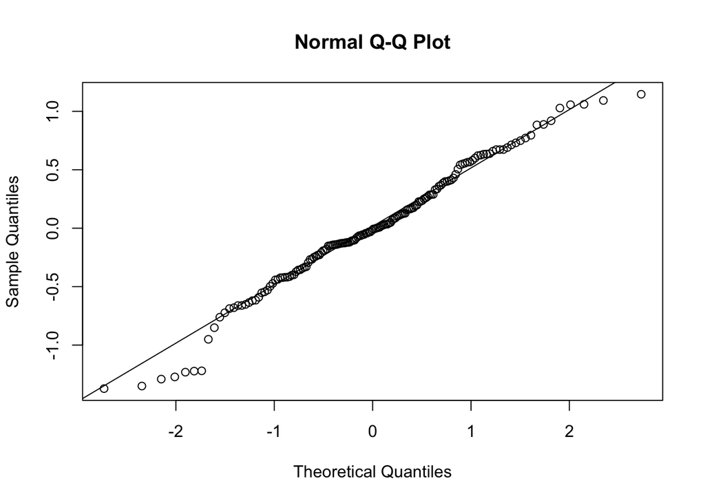

```r
{qqnorm(best.model.fit$residuals)
  qqline(best.model.fit$residuals)}
```

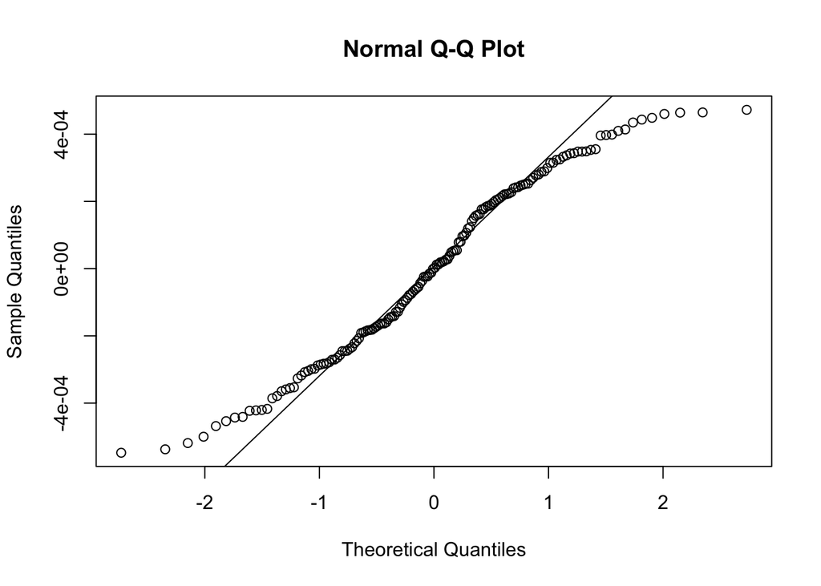

```r
{qqnorm(best.model.fit.2$residuals)
  qqline(best.model.fit.2$residuals)}
```

```r
best.model.fit.3 = lm(Happiness.Score ~ Economy..GDP.per.Capita. + Family + Region + Health..Life.Expectancy.+  Freedom + Trust..Government.Corruption. + Dystopia.Residual, data = world.happiness)
summary(best.model.fit.3)
```

```
##
## Call:
## lm(formula = Happiness.Score ~ Economy..GDP.per.Capita. + Family +
##     Region + Health..Life.Expectancy. + Freedom + Trust..Government.Corruption. +
##     Dystopia.Residual, data = world.happiness)
##
## Residuals:
##      Min       1Q   Median       3Q      Max
## -0.26565 -0.05416 -0.01318  0.04650  0.33787
##
## Coefficients:
##                                       Estimate Std. Error t value Pr(>|t|)
## (Intercept)                            0.39266    0.11474   3.422 0.000812 ***
## Economy..GDP.per.Capita.               0.85909    0.04146  20.720  < 2e-16 ***
## Family                                 1.07638    0.04369  24.639  < 2e-16 ***
## RegionCentral and Eastern Europe      -0.25046    0.07772  -3.223 0.001575 **
## RegionEastern Asia                    -0.18892    0.08442  -2.238 0.026789 *
## RegionLatin America and Caribbean     -0.20510    0.07758  -2.644 0.009117 **
## RegionMiddle East and Northern Africa -0.19622    0.07841  -2.502 0.013470 *
## RegionNorth America                    0.01815    0.10028   0.181 0.856599
## RegionSoutheastern Asia               -0.03220    0.08270  -0.389 0.697584
## RegionSouthern Asia                   -0.07456    0.08845  -0.843 0.400631
## RegionSub-Saharan Africa              -0.21516    0.08762  -2.455 0.015277 *
## RegionWestern Europe                  -0.11803    0.07470  -1.580 0.116314
## Health..Life.Expectancy.               1.07428    0.08156  13.171  < 2e-16 ***
## Freedom                                1.12870    0.07505  15.039  < 2e-16 ***
## Trust..Government.Corruption.          1.11602    0.08431  13.237  < 2e-16 ***
## Dystopia.Residual                      0.97672    0.01613  60.569  < 2e-16 ***
## ---
## Signif. codes:  0 '***' 0.001 '**' 0.01 '*' 0.05 '.' 0.1 ' ' 1
##
## Residual standard error: 0.09945 on 142 degrees of freedom
## Multiple R-squared:  0.9932, Adjusted R-squared:  0.9925
## F-statistic:  1378 on 15 and 142 DF,  p-value: < 2.2e-16
```

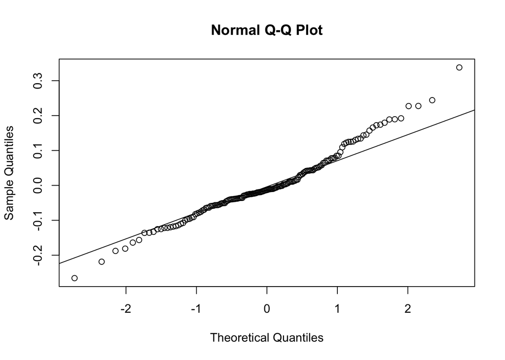

```r
{qqnorm(best.model.fit.3$residuals)
  qqline(best.model.fit.3$residuals)}
```